# Module 1

STAT 6021

Taylor R. Brown, PhD

# A brief tour

- Participation:
  - 10% (mostly reading comprehensions)
  - find them in the Tests & Quizzes tab
- Homeworks:
  - 25%
  - find them in the Assignments tab
- Project 1/2
  - 30%, 35% respectively

# Communicating

My email: `trb5me@virginia.edu`

slack: [`https://stat6021.slack.com/`](https://stat6021.slack.com/)

Other Information: Collab (e.g. syllabus)

# Getting started

Download Instructions for R:

Download R from here: http://archive.linux.duke.edu/cran/ See the first box at the top. Choose among Windows, Mac and Linux options.

Download RStudio Desktop from here: https://www.rstudio.com/products/rstudio/download/

# Getting started

Assignments are graded with [“gradeR”](https://cran.r-project.org/web/packages/gradeR/gradeR.pdf).

- assign your answers to the right variables
- use local paths (interactively use `setwd()`)
- don’t delete/overwrite variables later in the script

# Questions?

Questions before we start the material?

# Regression!

We want to develop a framework for modelling a dependence between a $Y$ and an $X$. The general form of a model would be

$$Y = f(X) + \epsilon$$

- $f(\cdot)$ is a function, and
- $\epsilon$ is a random error variable.

# Regression!

How do we get an idea for what $f(\cdot)$ should be?

Typically we plot $x_1, \ldots, x_n$ against $y_1, \ldots, y_n$. This is called a **scatterplot**.

# A scatterplot

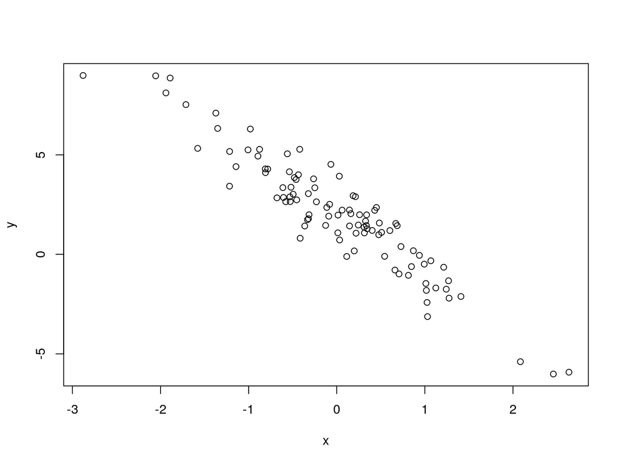

Theoretical/scientific justification is often useful

# A Workhorse: Simple Linear Regression

When there looks to be a linear relationship, we can use the **simple linear regression model**.

$$Y = \beta_0 +\beta_1 X + \epsilon$$

- $\beta_0$ is the nonrandom, unknown intercept
- $\beta_1$ is the nonrandom, unknown slope
- $\epsilon$ has mean $0$
- $V[\epsilon \mid X] = \sigma^2$

# The Conditional Distribution of $Y$ given $X$

$$\begin{align*}
E[Y \mid X] &= E[\beta_0 +\beta_1 X + \epsilon \mid X ] \\
&= \beta_0 +\beta_1 X + E[\epsilon \mid X] \\
&= \beta_0 + \beta_1 X
\end{align*}$$

$$\begin{align*}
V[Y \mid X ] &= V[\beta_0 +\beta_1 X + \epsilon \mid X ] \\
&= V[\epsilon \mid X ] \\
&= \sigma^2
\end{align*}$$

# The Conditional Distribution of $Y$ given $X$

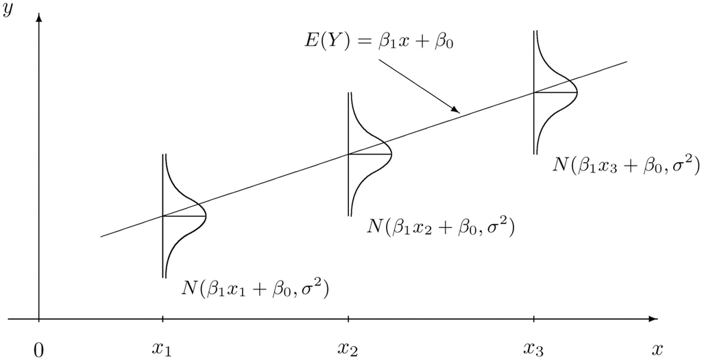

# Estimation

With an SLR model $Y = \beta_0 + \beta_1 X + \epsilon$.

We don’t know $\beta_0, \beta_1, \sigma^2$, so we have to use data to estimate these.

# Estimation

To estimate $\beta_0$ and $\beta_1$ we minimize the **loss**:
$$S(\beta_0, \beta_1) = \sum_{i=1}^n \left[ y_i - (\beta_0 + \beta_1 x_i)\right]^2$$

# Estimation

This is the loss-minimizing line:

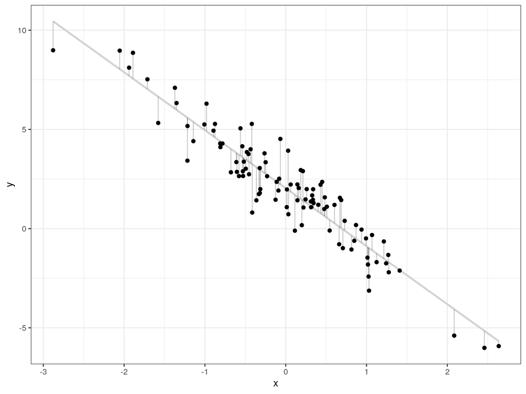

# Estimation

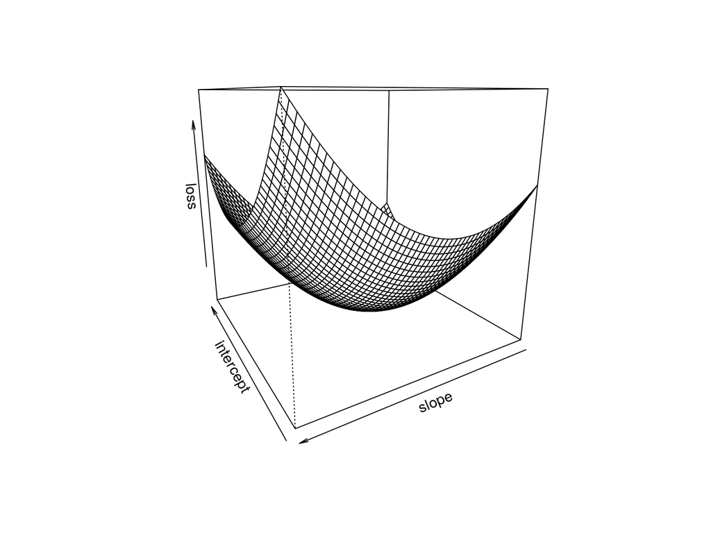

# Estimation

The $\hat{\beta_0}$ and $\hat{\beta_1}$ that minimize this are called the **least squares estimates**.

The **estimated regression line** is then
$$\hat{y} = \hat{\beta}_0 + \hat{\beta}_1 x$$

# Chain rule to the rescue

$$\begin{align*}
\frac{\partial}{\partial \beta_0} S(\beta_0, \beta_1) &= \frac{\partial}{\partial \beta_0}\sum_{i=1}^n ( y_i - \beta_0 - \beta_1 x_i)^2 \\
&= \sum_{i=1}^n \frac{\partial}{\partial \beta_0}( y_i - \beta_0 - \beta_1 x_i)^2 \\
&= \sum_{i=1}^n 2 ( y_i - \beta_0 - \beta_1 x_i) (-1) \\
&\overset{\text{set}}{=}0
\end{align*}$$

$$\begin{align*}
\frac{\partial}{\partial \beta_1} S(\beta_0, \beta_1) &= \frac{\partial}{\partial \beta_1}\sum_{i=1}^n ( y_i - \beta_0 - \beta_1 x_i)^2 \\
&= \sum_{i=1}^n \frac{\partial}{\partial \beta_1}( y_i - \beta_0 - \beta_1 x_i)^2 \\
&= \sum_{i=1}^n 2 ( y_i - \beta_0 - \beta_1 x_i) (-x_i) \\
&\overset{\text{set}}{=}0
\end{align*}$$

# The normal equations

The **normal equations** are what you get when you re-arrange things to get rid of negative signs:

$$n\hat{\beta}_0 + \left(\sum_i x_i \right)\hat{\beta}_1 = \sum_i y_i$$

$$\left(\sum_i x_i \right)\hat{\beta}_0 + \left(\sum_i x_i^2 \right) \hat{\beta}_1 = \sum_i x_i y_i$$

Sometimes people divide through by $n$

$$\hat{\beta}_0 + \bar{x}\hat{\beta}_1 = \bar{y}$$

$$\bar{x}\hat{\beta}_0 + \frac{\sum_i x_i^2 }{n} \hat{\beta}_1 = \frac{\sum_i x_i y_i}{n}$$

# The final solution

finishing off the work, we solve for $\hat{\beta}_0$ and $\hat{\beta}_1$
$$\hat{\beta}_0 = \bar{y} - \hat{\beta}_1 \bar{x}$$

$$\hat{\beta}_1 = \frac{\sum_i x_i y_i - n \bar{x}\bar{y}}{\sum_i x_i^2 - n\bar{x}^2} = \frac{\sum_i(x_i - \bar{x})(y_i - \bar{y})}{\sum_j (x_j - \bar{x})^2}$$

# The fitted values

To get the **fitted (predicted) values**, denoted $\hat{y}_1, \hat{y}_2, \ldots, \hat{y}_n$, are what you get when you plug in $x_1, \ldots, x_n$ into the estimated regression line $\hat{\beta}_0 + \hat{\beta}_1x$.

$$\hat{y}_i = \hat{\beta}_0 + \hat{\beta}_1 x_i$$
for $i = 1, \ldots, n$.

# A Trick

$$\hat{\beta}_1 = \sum_i c_i y_i$$

where
$$c_i = \frac{(x_i - \bar{x}) }{\sum_{j=1}^n (x_j - \bar{x})^2 } = \frac{(x_i - \bar{x}) }{S_{xx}} .$$

The following equation is true by definition: $\sum(x_i - \bar{x})^2 = S_{xx}$.

# A Trick

Why:

$$\begin{align*}
\hat{\beta}_1 &= \frac{\sum_i (x_i - \bar{x})(y_i - \bar{y})}{S_{xx}} \\
&= \frac{\sum_i (x_i - \bar{x})y_i - \sum (x_i - \bar{x})\bar{y}}{S_{xx}}\\
&= \frac{\sum_i (x_i - \bar{x})y_i }{S_{xx}} \\
&= \sum_i c_i y_i
\end{align*}$$

because $\sum(x_i - \bar{x}) = 0$.

# showing unbiasedness with our new trick

Drop from notation dependence on $x_1, \ldots, x_n$…

$$\begin{align*}
E[\hat{\beta}_1 ] &= E[ \sum_i c_i y_i ] \\
&= \sum_i c_i E[y_i] \\
&= \sum_i c_i E[\beta_0 + \beta_1 x_i + \epsilon_i ] \\
&= \sum_i c_i [\beta_0 + \beta_1 x_i ] \\
&= \beta_0 \sum_i c_i + \beta_1 \sum_i c_i x_i \\
&= \beta_0 \sum_i \frac{(x_i - \bar{x}) }{S_{xx}} + \beta_1 \sum_i \frac{(x_i - \bar{x}) }{S_{xx}} x_i \\
&= \beta_1 \sum_i x_i \frac{(x_i - \bar{x}) }{S_{xx}} \\
&= \beta_1 \sum_i \frac{(x_i - \bar{x})^2 }{S_{xx}} \\
&= \beta_1
\end{align*}$$

# calculating the variance with our new trick

$$\begin{align*}
V[\hat{\beta}_1 ] &= V[ \sum_i c_i y_i ] \\
&= \sum_i c_i^2 V[y_i] \\
&= \sum_i c_i^2 V[\beta_0 + \beta_1 x_i + \epsilon_i ] \\
&= \sum_i c_i^2 \sigma^2 \\
&= \sigma^2 \sum_i \frac{(x_i - \bar{x})^2 }{S_{xx}^2} \\
&= \sigma^2 \frac{S_{xx} }{S_{xx}^2} \\
&= \frac{\sigma^2 }{S_{xx}}
\end{align*}$$

# mean of intercept

Similarly
$$E[\hat{\beta}_0]= E[\bar{y} - \hat{\beta}_1 \bar{x}] = E[\bar{y}] - \beta_1\bar{x} = \beta_0$$

$$V[\hat{\beta}_0]= \sigma^2\left(\frac{1}{n} + \frac{\bar{x}^2}{S_{xx}} \right)$$

# Estimating the third parameter

Estimating $\sigma^2$ can be done by taking the average squared error

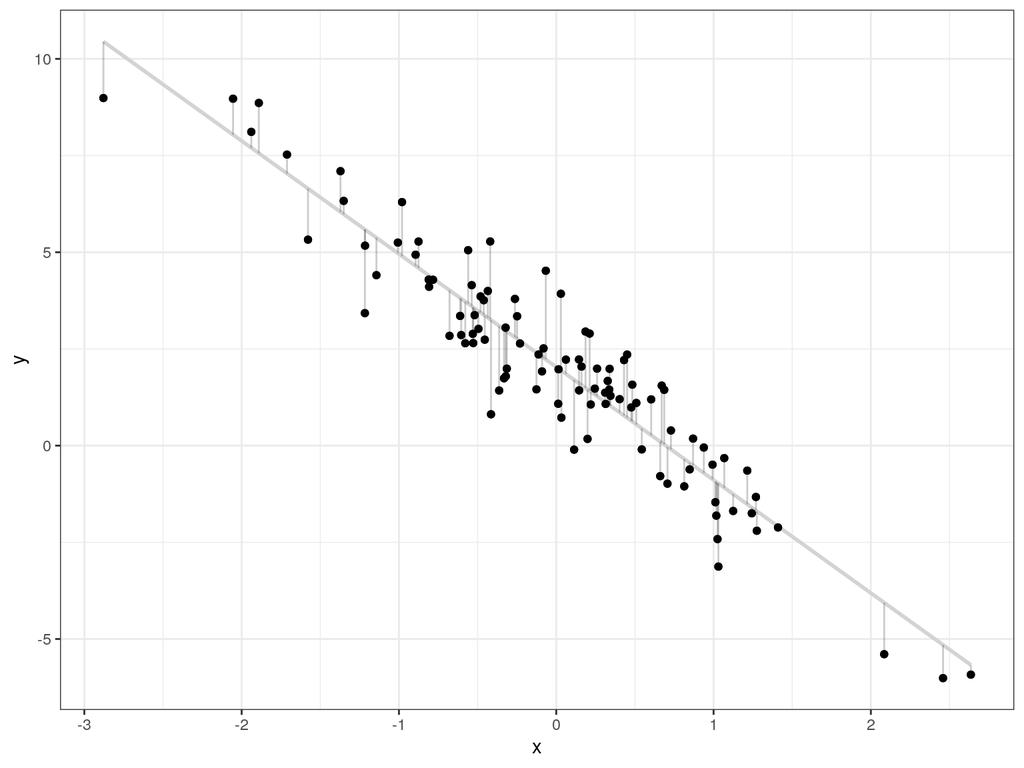

# Estimating the third parameter

$$\hat{\sigma}^2 = \frac{\sum_{i=1}^n (y_i - \hat{y}_i )^2 }{n-2} = \frac{SS_{\text{res}} }{n-2}.$$
Note we use $n-2$ instead of $n$.

In the next chapter, we call $\hat{\sigma}^2 = \text{MS}_{Res}$.

# Sums of Squares

$$SS_T = SS_R + SS_{Res}$$
or
$$\sum_{i=1}^n (y_i - \bar{y})^2 = \sum_{i=1}^n (y_i - \hat{y}_i)^2 + \sum_{i=1}^n (\hat{y}_i - \bar{y})^2$$

Breaking up *total sums of squares* into good and bad pieces has a few other uses

# Sums of Squares

$$\begin{align*}
\sum_{i=1}^n (y_i - \bar{y})^2 &= \sum_{i=1}^n (y_i -\hat{y}_i + \hat{y}_i - \bar{y})^2 \\
&=\sum_{i=1}^n (y_i - \hat{y}_i)^2 + \sum_{i=1}^n (\hat{y}_i - \bar{y})^2 + 2 \sum_{i=1}^n (y_i - \hat{y}_i)(\hat{y}_i - \bar{y})
\end{align*}$$

use the normal equations on that last piece:

$$\begin{align*}
\sum_{i=1}^n (y_i - \hat{y}_i)(\hat{y}_i - \bar{y}) &= \sum_{i=1}^n (y_i - \hat{y}_i)\hat{y}_i - \bar{y} \sum_{i=1}^n (y_i - \hat{y}_i)
\end{align*}$$

it’s clearer after you write

$$\begin{align*}
\sum_{i=1}^n (y_i - \hat{y}_i)\hat{y}_i &= \sum_{i=1}^n (y_i - \hat{y}_i)(\hat{\beta}_0 + \hat{\beta}_1 x_i ) \\
&= \hat{\beta}_0 \sum_{i=1}^n (y_i - \hat{y}_i) + \hat{\beta}_1\sum_{i=1}^n (y_i - \hat{y}_i) x_i
\end{align*}$$

# Coefficient of Determination

$$R^2 = \frac{SS_R}{SS_T}$$
“the proportion of variation explained by the regressor x”

# `R` examples!

```r
setwd("/home/t/UVa/all_teaching/summer19_6021/data")
my_data <- read.csv("data-table-B3.csv")
head(my_data) # always check that it worked
```

```
##       y  x1  x2  x3   x4   x5 x6 x7    x8   x9  x10 x11
## 1 18.90 350 165 260 8.00 2.56  4  3 200.3 69.9 3910   1
## 2 17.00 350 170 275 8.50 2.56  4  3 199.6 72.9 3860   1
## 3 20.00 250 105 185 8.25 2.73  1  3 196.7 72.2 3510   1
## 4 18.25 351 143 255 8.00 3.00  2  3 199.9 74.0 3890   1
## 5 20.07 225  95 170 8.40 2.76  1  3 194.1 71.8 3365   0
## 6 11.20 440 215 330 8.20 2.88  4  3 184.5 69.0 4215   1
```

# `R` examples!

```r
reg_mod_1 <- lm(y ~ x1, data = my_data)
summary(reg_mod_1)  # print a lot
```

```
##
## Call:
## lm(formula = y ~ x1, data = my_data)
##
## Residuals:
##     Min      1Q  Median      3Q     Max
## -6.7923 -1.9752  0.0044  1.7677  6.8171
##
## Coefficients:
##              Estimate Std. Error t value Pr(>|t|)
## (Intercept) 33.722677   1.443903   23.36  < 2e-16 ***
## x1          -0.047360   0.004695  -10.09 3.74e-11 ***
## ---
## Signif. codes:  0 '***' 0.001 '**' 0.01 '*' 0.05 '.' 0.1 ' ' 1
##
## Residual standard error: 3.065 on 30 degrees of freedom
## Multiple R-squared:  0.7723, Adjusted R-squared:  0.7647
## F-statistic: 101.7 on 1 and 30 DF,  p-value: 3.743e-11
```

# `R` examples!

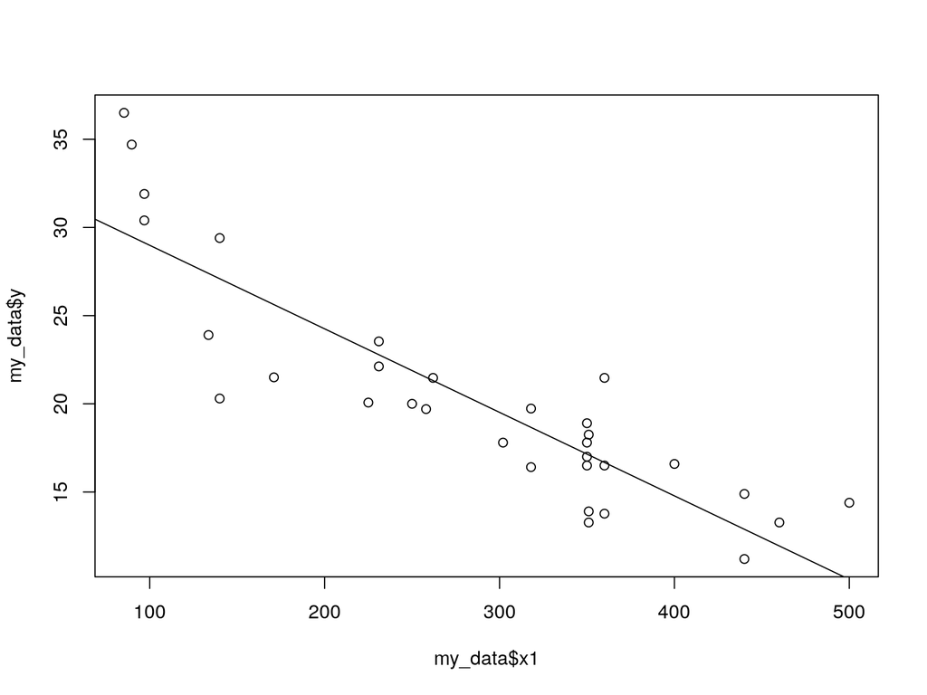

```r
plot(my_data$x1, my_data$y)
abline(reg_mod_1)  # overlay the best fit line
```